# Bathymetric maps in R

Hansen Johnson

2018-03-19

> Updated 2018-10-17 to replace `ggmap` with `ggplot2`

There are a number of different ways to make basic maps in R. In the last year or so I’ve become a big fan of [leaflet](http://leafletjs.com/) and the [R leaflet](https://rstudio.github.io/leaflet/) package that makes these maps a breeze to build in `R`. Leaflet makes very nice online interactive maps, but doesn’t provide a great option for a static map like you would put in a publication or presentation. I’ve jumped around between a few different methods for making static maps, but for the purposes of this post I’ll focus on a few that I like and use most.

The first method uses the [oce](http://dankelley.github.io/oce/) package, developed primarily by Dan Kelley and Clark Richards at my native Dalhousie. The other uses the [ggplot2](https://ggplot2.tidyverse.org/) package, which is the brainchild of Hadley Wickham and others in the [tidyverse](https://www.tidyverse.org/) crowd. My plan is to present simple reproducible examples for each map-making method to show how to use them to display basic types of spatial data: contours (bathymetry), lines, points, and polygons.

## Get data

Step one is to get the data that we’ll be plotting. A very handy tool for this is the `getNOAA.bathy()` function from the [marmap](https://cran.r-project.org/web/packages/marmap/index.html) package, which, perhaps not surprisingly, gets user-selected bathymetric data from the NOAA ETOPO database. There are a number of other great functions within `marmap`, but, for reasons I won’t get into here, I’ve never quite been satisfied with using it to make maps. Anyway, here’s the data I’ll be using:

```r
library(marmap)

# get bathymetry data
b = getNOAA.bathy(lon1 = -68, lon2 = -62, lat1 = 40, lat2 = 45,
                  resolution = 1)
## Querying NOAA database ...
## This may take seconds to minutes, depending on grid size
## Building bathy matrix ...

# make a simple track line
lin = data.frame(
  lon = c(-65.17536, -65.37423, -65.64541, -66.06122, -66.15161),
  lat = c(43.30837, 42.94679, 42.87448, 42.92871, 42.72985)
)

# make a few points
pts = data.frame(
  lon = c(-65.3, -65.7, -64.1),
  lat = c(43.4, 43, 42.9)
)

# build a polygon (in this case the 'Roseway Basin Area To Be Avoided')
ply = data.frame(
  lon = c(-64.916667,-64.983333,-65.516667, -66.083333),
  lat = c(43.266667,  42.783333, 42.65, 42.866667)
)
```

## oce

The following map with `oce` does not use a projection, which basically means that all plotting occurs as if the world were completely flat. Plotting in this way is quick and convenient, especially because it allows you to use all of `R`’s base graphic functions, but is not appropriate in many cases. I typically use this approach when plotting relatively small areas (maybe 10s of kilometers) and in circumstances where exact distances aren’t crticially important.

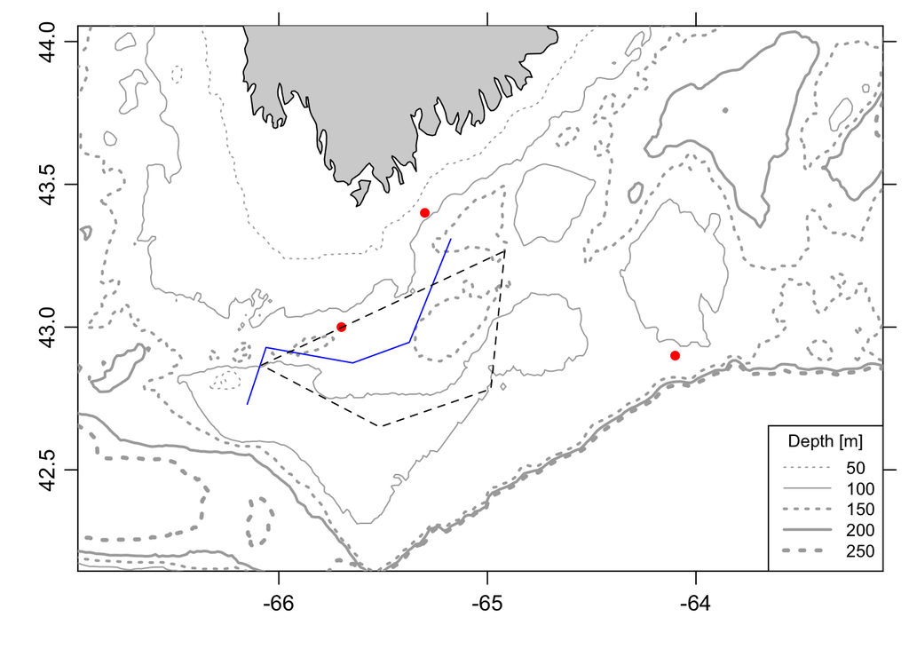

```r
library(oce)
library(ocedata)
data("coastlineWorldFine")

# convert bathymetry
bathyLon = as.numeric(rownames(b))
bathyLat = as.numeric(colnames(b))
bathyZ = as.numeric(b)
dim(bathyZ) = dim(b)

# define plotting region
mlon = mean(pts$lon)
mlat = mean(pts$lat)
span = 300

# plot coastline (no projection)
plot(coastlineWorldFine, clon = mlon, clat = mlat, span = span)

# plot bathymetry
contour(bathyLon,bathyLat,bathyZ,
        levels = c(-50, -100, -150, -200, -250),
        lwd = c(1, 1, 2, 2, 3),
        lty = c(3, 1, 3, 1, 3),
        drawlabels = F, add = TRUE, col = 'darkgray')

# add depth legend
legend("bottomright", seg.len = 3, cex = 0.8,
       lwd = c(1, 1, 2, 2, 3),
       lty = c(3, 1, 3, 1, 3),
       legend = c("50", "100", "150", "200", "250"),
       col = 'darkgray', title = "Depth [m]", bg= "white")

# add map data
points(pts, pch = 16, col = 'red')
lines(lin, col = 'blue')
polygon(ply, lty = 2)
```